# Content Creation Patterns: A Data-Driven Vlog Strategy

Juseok Lee

Introduction Building on the video observation project from Semester One, I have expanded my data collection to focus on content creation patterns across my VLOGs. In this phase, I introduced new categorical variables such as title language and whether the thumbnail features a person’s face. By analysing these observations, I aim to understand how technical choices—like video length and language—affect audience interaction (views and comments).

## 1. Average Views by Video Category

The first step in my analysis was to determine which type of content performs best on average. By grouping the data by video type, I could see a clear comparison between different categories.

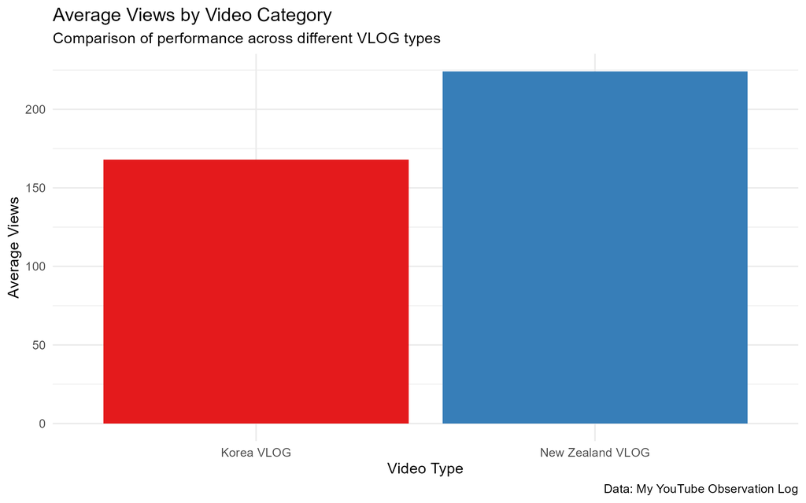

This visualisation helps identify which topics are currently most appealing to the audience, allowing for a more focused content strategy in future uploads.

## 2. Impact of Language on Video Reach

As an international creator, I often choose between Korean and English for my video titles. I used a boxplot to see how this choice influences the distribution of total views.

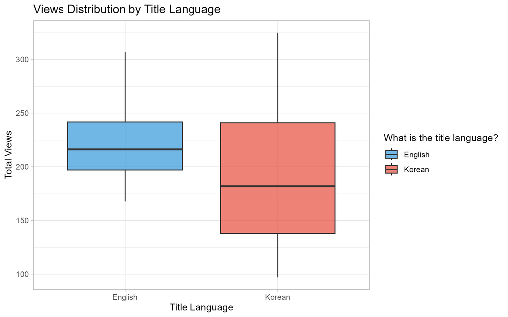

The distribution shows not just the average, but also the range of performance, helping me decide if English titles truly help in reaching a wider global audience compared to Korean titles.

## 3. Optimal Upload Timing: Day of the Week Analysis

Finally, I utilized the Timestamp variable from my logging data to determine the best days for audience reach. By using the {lubridate} package to extract days of the week, I could analyze how view counts vary depending on when a video is published.

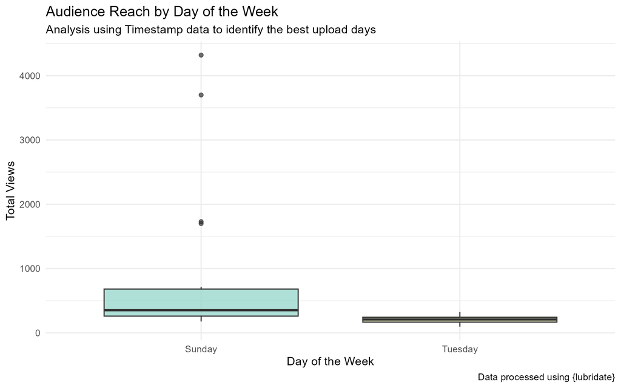

This boxplot reveals the distribution of engagement across different days, helping to identify peak performance periods. Such insights are crucial for developing a data-driven upload schedule that maximizes initial viewer traction.